# Evaluation-of-filter-results_25x50

Kento Okuyama

2023-11-08

## (very) Brief introduction

In this document, we evaluate the implementation of our frequentist implementation of the non-linear regime-switching state-space (RSSS) model estimation based on simulated data. Our parameter optimization consists of 300 iteration steps based on Adam. On top of that, we have 30 initialization of the starting parameter values.

In our implementation, our objective function **sumLik** is maximized based on the gradient vector and Adam. For evaluation purpose, we also have the score function **delta**. This is simply calculated as the summed squared error of the one-step-ahead (of the last observed time points) prediction of our intra-individual latent variables. Further, we also have **sensitivity** and **specificity** based on the one-step-ahead regime prediction results.

### N=25, T=50

First, we check the distribution of the resulting **sumLik**

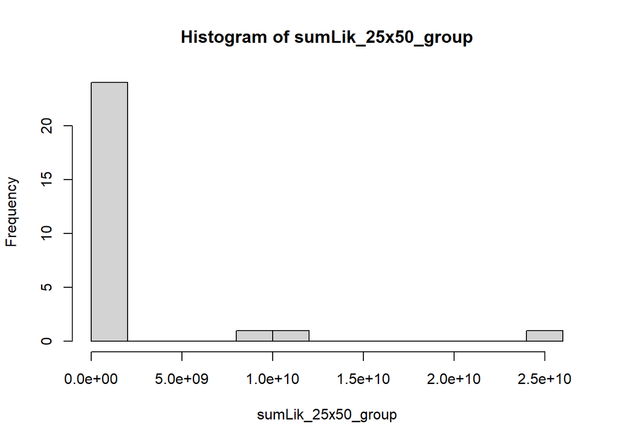

```r
hist(sumLik_25x50_group, breaks=15)
```

```r
summary(sumLik_25x50_group)
```

```
##      Min.   1st Qu.    Median      Mean   3rd Qu.      Max.
## 0.000e+00 0.000e+00 0.000e+00 1.661e+09 8.700e+01 2.480e+10
```

and in log scale

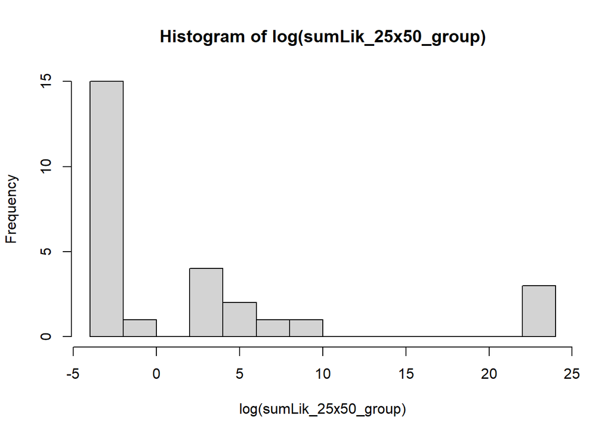

```r
hist(log(sumLik_25x50_group), breaks=10)
```

```r
summary(log(sumLik_25x50_group))
```

```
##    Min. 1st Qu.  Median    Mean 3rd Qu.    Max.
##  -3.765  -3.316  -2.168   2.263   4.249  23.934
```

It seems like there are a few instances which has much higher **sumLik** than others.

Second, we check the distribution of the resulting **delta**

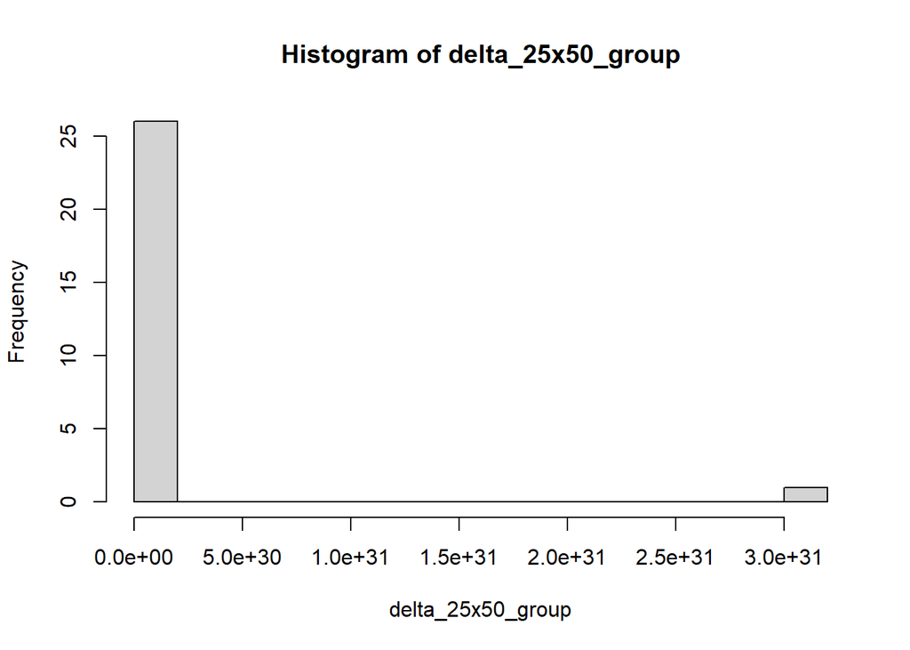

```r
hist(delta_25x50_group, breaks=15)
```

```r
summary(delta_25x50_group)
```

```
##      Min.   1st Qu.    Median      Mean   3rd Qu.      Max.
## 0.000e+00 0.000e+00 0.000e+00 1.128e+30 0.000e+00 3.047e+31
```

and in log scale

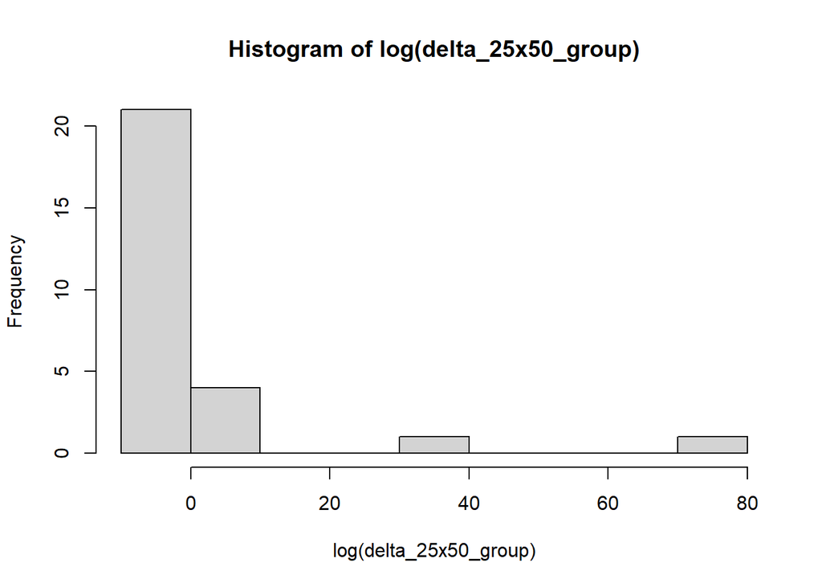

```r
hist(log(delta_25x50_group), breaks=10)
```

```r
summary(log(delta_25x50_group))
```

```
##    Min. 1st Qu.  Median    Mean 3rd Qu.    Max.
## -1.7293 -1.4468 -1.2840  2.9166 -0.8486 72.4942
```

Please note that we prefer a smaller value as it is calculated based on the prediction error.

Next, we turn our attention to how the **sumLik** and **delta** correlate. Intuitively, we expect the negative correlation so that higher **sumLik** (maximized likelihood) relates to smaller **delta** (smaller prediction error).

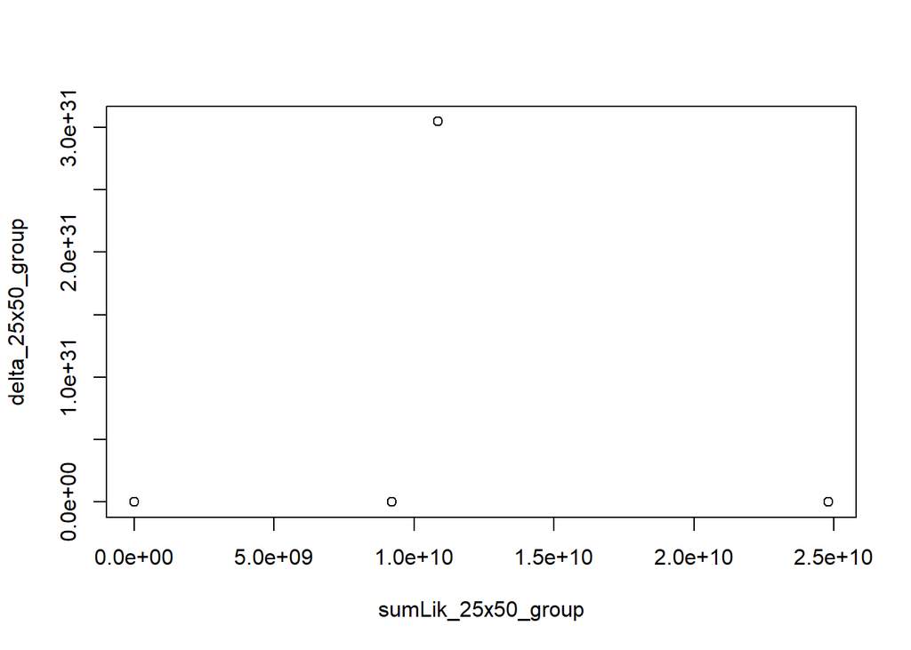

```r
plot(sumLik_25x50_group, delta_25x50_group)
```

```r
cor(sumLik_25x50_group, delta_25x50_group)
```

```
## [1] 0.3436855
```

and in log scale

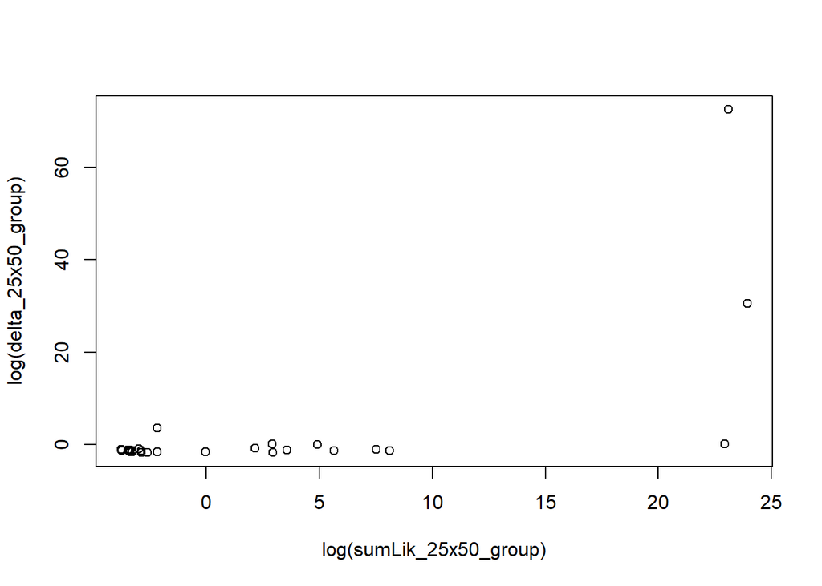

```r
plot(log(sumLik_25x50_group), log(delta_25x50_group))
```

```r
cor(log(sumLik_25x50_group), log(delta_25x50_group))
```

```
## [1] 0.6729885
```

Unfortunately, we see a positive correlation between **sumLik** and **delta**.

Then, we check the distribution of **sensitivity** and **specificity**.

First for **sensitivity**

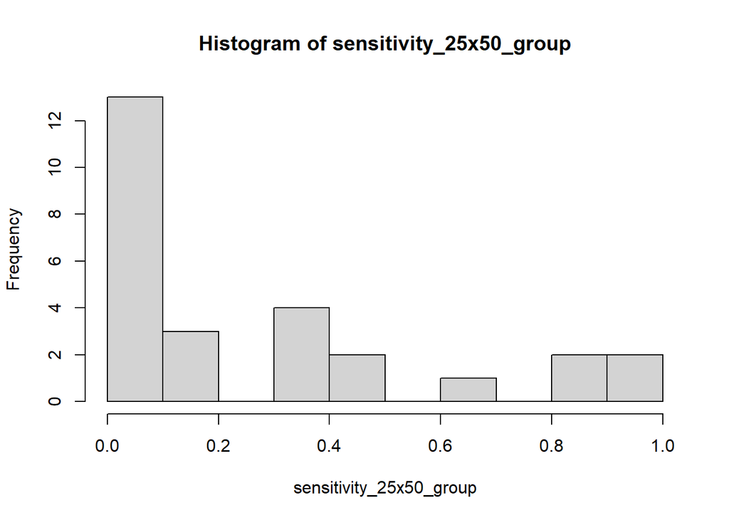

```r
hist(sensitivity_25x50_group, breaks=10)
```

```r
summary(sensitivity_25x50_group)
```

```
##    Min. 1st Qu.  Median    Mean 3rd Qu.    Max.
##  0.0000  0.0000  0.1667  0.2778  0.4500  1.0000
```

And for **specificity**

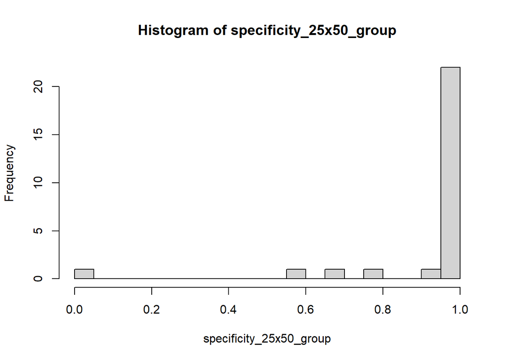

```r
hist(specificity_25x50_group, breaks=15)
```

```r
summary(specificity_25x50_group)
```

```
##    Min. 1st Qu.  Median    Mean 3rd Qu.    Max.
##  0.0000  1.0000  1.0000  0.9241  1.0000  1.0000
```

We can also check the correlation between **sensitivity** and **specificity**.

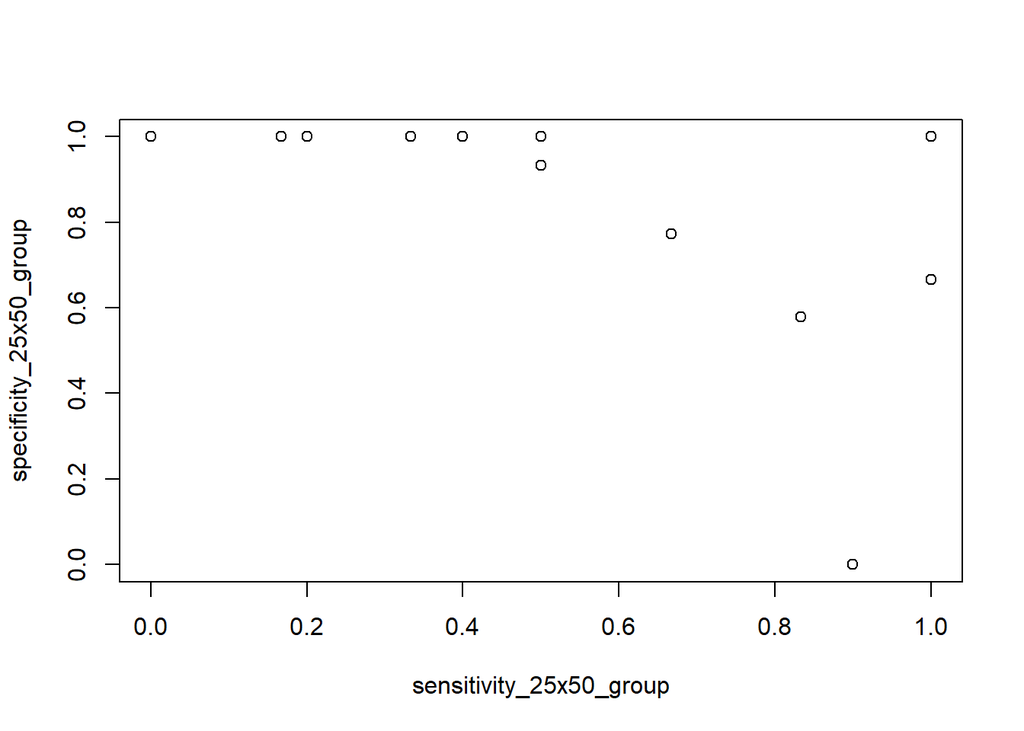

```r
plot(sensitivity_25x50_group, specificity_25x50_group)
```

```r
cor(sensitivity_25x50_group, specificity_25x50_group)
```

```
## [1] -0.6286734
```

Finally we examine our parameter estimation.

The distribution of parameter estimation are shown below. True parameter values are in parenthesis.

```r
summary(theta_25x50_group)
```

```
##    B11_1 (.2)          B11_2 (.3)       B12_1 (-.1)        B12_2 (-.2)
##  Min.   :-0.006098   Min.   :0.02977   Min.   :-0.43331   Min.   :-0.396591
##  1st Qu.: 0.103373   1st Qu.:0.12165   1st Qu.:-0.27084   1st Qu.:-0.189794
##  Median : 0.161792   Median :0.17168   Median :-0.18636   Median :-0.122216
##  Mean   : 0.153470   Mean   :0.20888   Mean   :-0.18656   Mean   :-0.145702
##  3rd Qu.: 0.188562   3rd Qu.:0.30447   3rd Qu.:-0.13281   3rd Qu.:-0.072424
##  Max.   : 0.389730   Max.   :0.53805   Max.   : 0.09856   Max.   : 0.007234
##   B21d_1 (.8)      B21d_2 (.8)      B22d_1 (.4)         B22d_2 (.4)
##  Min.   :0.6433   Min.   :0.5387   Min.   :0.0000098   Min.   :-0.01636
##  1st Qu.:0.7540   1st Qu.:0.7608   1st Qu.:0.1112435   1st Qu.: 0.02123
##  Median :0.8314   Median :0.8683   Median :0.2697244   Median : 0.13928
##  Mean   :0.8274   Mean   :0.8304   Mean   :0.2240664   Mean   : 0.17451
##  3rd Qu.:0.8889   3rd Qu.:0.8934   3rd Qu.:0.3054707   3rd Qu.: 0.29906
##  Max.   :0.9848   Max.   :1.0039   Max.   :0.4445530   Max.   : 0.45366
##    B31_1 (.1)          B31_2 (.1)        B32_1 (-.1)        B31_2 (-.1)
##  Min.   :-0.329616   Min.   :-0.36536   Min.   :-0.46457   Min.   :-0.28607
##  1st Qu.:-0.001068   1st Qu.:-0.05330   1st Qu.:-0.12976   1st Qu.:-0.12270
##  Median : 0.097754   Median : 0.08787   Median :-0.01988   Median :-0.08124
##  Mean   : 0.084795   Mean   : 0.05312   Mean   :-0.04321   Mean   :-0.07746
##  3rd Qu.: 0.168056   3rd Qu.: 0.15831   3rd Qu.: 0.05220   3rd Qu.:-0.02351
##  Max.   : 0.385918   Max.   : 0.38373   Max.   : 0.26022   Max.   : 0.20438
##    Lmdd_1 (1)   Lmdd_2 (0)  Lmdd_3 (.4)       Lmdd_4 (0)  Lmdd_5 (.8)
##  Min.   :1    Min.   :0    Min.   :0.2985   Min.   :0    Min.   :0.5472
##  1st Qu.:1    1st Qu.:0    1st Qu.:0.5689   1st Qu.:0    1st Qu.:0.7989
##  Median :1    Median :0    Median :0.7866   Median :0    Median :0.8847
##  Mean   :1    Mean   :0    Mean   :0.7673   Mean   :0    Mean   :0.9123
##  3rd Qu.:1    3rd Qu.:0    3rd Qu.:1.0006   3rd Qu.:0    3rd Qu.:1.0440
##  Max.   :1    Max.   :0    Max.   :1.2901   Max.   :0    Max.   :1.3586
##    Lmdd_6 (0)   Lmdd_7 (0)   Lmdd_8 (1)   Lmdd_9 (0)  Lmdd_10 (.5)
##  Min.   :0    Min.   :0    Min.   :1    Min.   :0    Min.   :0.3220
##  1st Qu.:0    1st Qu.:0    1st Qu.:1    1st Qu.:0    1st Qu.:0.6045
##  Median :0    Median :0    Median :1    Median :0    Median :0.7451
##  Mean   :0    Mean   :0    Mean   :1    Mean   :0    Mean   :0.8297
##  3rd Qu.:0    3rd Qu.:0    3rd Qu.:1    3rd Qu.:0    3rd Qu.:1.1287
##  Max.   :0    Max.   :0    Max.   :1    Max.   :0    Max.   :1.3572
##   Lmdd_11 (0) Lmdd_12 (1.2)      Qd_1 (.2)          Qd_2 (.2)
##  Min.   :0    Min.   :0.6477   Min.   :0.001000   Min.   :0.001000
##  1st Qu.:0    1st Qu.:0.9862   1st Qu.:0.002387   1st Qu.:0.001815
##  Median :0    Median :1.1378   Median :0.172370   Median :0.171210
##  Mean   :0    Mean   :1.0908   Mean   :0.091604   Mean   :0.091648
```

[output cut: 8 more lines]

```
##  Max.   :0.37950   Max.   :0.37795   Max.   :0.37730   Max.   :0.37909
##    Rd_5 (.3)         Rd_6 (.3)        gamma1 (3.5)    gamma2_1 (1)
##  Min.   :0.02049   Min.   :0.04654   Min.   :4.013   Min.   :0.1379
##  1st Qu.:0.05479   1st Qu.:0.08659   1st Qu.:4.122   1st Qu.:0.5157
##  Median :0.37139   Median :0.37047   Median :4.124   Median :0.6932
##  Mean   :0.22483   Mean   :0.24477   Mean   :4.251   Mean   :0.9573
##  3rd Qu.:0.37465   3rd Qu.:0.37353   3rd Qu.:4.406   3rd Qu.:1.4580
##  Max.   :0.38023   Max.   :0.40088   Max.   :4.631   Max.   :2.4080
##   gamma2_2 (1)
##  Min.   :0.3813
##  1st Qu.:0.5258
##  Median :0.9659
##  Mean   :1.0088
##  3rd Qu.:1.2947
##  Max.   :2.0536
```